# Time Series multivariate forecast

Crystal Lwi

02/09/2021

## Time Series Analysis

This is a sample code that was implemented to demonstrate ability to perform multivariate time-series data.

```r
## Select by start Train, Test date and Columns x + y
prepMonthlyData <- function (monthly_data, set, start_train_date, end_test_date, crude = CRUDE,
                             featuresSelected = featuresSelected){
    if (crude == "diff"){
        crude_column <- "crude_diff"
    }else{
        crude_column <- paste0(as.character(crude), "_crude")
    }
    if (sum(grepl("DateTime" , names(monthly_data)) >= 1)){
        monthly_data <- monthly_data %>% rename(Date = DateTime)
    }
    monthly_data_prep <- monthly_data %>%
        # Filter Train Test date
        filter(Date >= start_train_date[set], Date <= end_test_date[set])%>%
        arrange(Date) %>%
        # Select target + predictor columns
        select(!!rlang::sym(crude_column), one_of(featuresSelected))

    return (monthly_data_prep)
}
```

## Multivariate model using Linear model.

We implement a fitControl basis a time-series cross validation method. We also used an existing `timetk` library method to prepare our lagging dataframes.

The horizons are hard-coded to basically say we are forecasting up to 12-horizons. Lookback is to enable model to use lag variables during the model fitting process.

Model fitting is done in this example with the implementation of `caret` package.

Since there was scaling done during model-fitting, we then inverse the predictions using scaled values with the `invertScale` function.

```r
model_functionLMv2 <- function (data_df, fitControl, date_range, crude = CRUDE,
                                featuresSelected, YEAR){
    #' This function splits data_df into train and test, lags the dataframe.
    #' This is function to train lag 12 months data with XGBoost model.
    #'@param data_df = Monthly Data with y and x-vars no lag that has been subset according to the right
    #'                 end test date
    #'@param fitControl = Cross validation tuning for Boosted LM Model
    #'@param date_range = Test start date for predictions table
    #'@param crude = String indicating target_variable in data_df (e.g. "brent"/"dubai")
    #'@param featuresSelected = vector of column names to be included as x-vars in the model.
    #'@param YEAR = 2019/ 2020
    #'@return list(train_data, test_data, model_fit, predictions)

    ptm <- proc.time()
    ## Select x-vars
    crude_column <- paste0(as.character(crude), "_crude")
    trainSet <- data_df %>%
        select(!!rlang::sym(crude_column), one_of(featuresSelected)) %>% as.data.frame()

    ## Customise horizons and lookback
    horizons <- 12 # Forecast M1, M2...M12
    lookback <- 1:12 # lag months

    ## Lag Train Test Set
    data_train <- create_lagged_df(trainSet, type = "train", method = "direct",
                                   outcome_col = 1, lookback = lookback,
                                   horizons = horizons)
    lag12_df <- data_train[[1]]
    data_test <- create_lagged_df(trainSet, type = "forecast", method = "direct",
                                  outcome_col = 1, horizons = horizons,
                                  lookback = lookback)
    lag12_df_test <- data_test[[1]]

    ## Scale Train, Scale Test
    train_x <- lag12_df %>% minmax_scaling()
    test_x <- lag12_df_test %>% select(one_of(names(train_x))) %>% minmax_scaling()

    ## Get Min Max Values
    min_y <- lag12_df %>% select(!!rlang::sym(crude_column)) %>% min(.)
    max_y <- lag12_df %>% select(!!rlang::sym(crude_column)) %>% max(.)

    print (paste("Training using Linear Model for", date_range, "as M0..."))
    set.seed(123)
    ## Fitting into Linear Model
    model_lm <- caret::train(as.formula(paste0(crude_column, "~.")),
                             train_x,
                             method = "lm",
                             trControl= fitControl)

    ## Saving model to RDS file
    saveRDS(model_lm, paste0("../data/output/Linear Model/Models/LM", tools::toTitleCase(crude), "Crude_ModelLag",
                          max(horizons), "v4_", month.abb[month(date_range)], YEAR, ".RDS"))

    ## 2019 Rolling Predict on Test Set
    if (YEAR == 2019){
        predicted <- invertScale(predictions = predict(model_lm, test_x),
                                 min_y = min_y, max_y = max_y)
        predictions <- data.frame("y_test" = round(predicted, 2)) %>%
            mutate(DateTime = seq_monthly(as.Date(date_range), nrow(.)),
                   forecast = paste("M", row_number()-1, sep = ""))
    }else{
        ## 2020 Rolling Predictions on Test Set
        predicted <- invertScale(predictions = predict(model_lm, test_x),
                                 min_y = min_y, max_y = max_y)
        predictions <- data.frame("y_test" = round(predicted, 2)) %>%
            mutate(DateTime = seq_monthly(as.Date(date_range), nrow(.)),
                   forecast = paste("M", row_number()-1, sep = ""))
    }
    print (proc.time() - ptm)
    gc()

    return (list("train_data" = lag12_df,
                 "test_data"= lag12_df_test,
                 "model" = model_lm,
                 "results" = predictions))
}
```

An advanced version of implementation of the workflow is then designed using `recipes and workflow.`

```
MonthlyM0M5Crudev5j <- function(all_features_merged, CRUDE){
  #'@param    all_features_merged [dataframe] Monthly dataframe, x-y features column.
  #'@param    CRUDE [str] Vector of length 1 ("brent" or "dubai")
  #'@return The monthly forecast value.

  #'--- Training, Testing Date
  length <- length(seq(from=as.Date("2019-01-01"), to=Sys.Date(), by='month'))
  start_train_date <- seq_monthly(as.Date("2014-01-01"), length = length) # Can select for different year
  end_test_date <- seq_monthly(as.Date("2018-12-31"), length = length)
  date_range <- seq_monthly(as.Date("2019-01-01"), length = length)
  crudeCol <- paste(CRUDE, "crude", sep = "_")
  CRACK <- ""
  featuresSelected <- get_features(model_version = "v5j")

  # Include / excluding Lag of crude prices as x-var.
  LAGCRUDE <- FALSE
  FORWARDFLAG <- TRUE
  forecast_horizon <- 6

  all_features_merged <- all_features_merged %>%
    dplyr::select(date_time, one_of(crudeCol), all_of(featuresSelected)) %>%
    dplyr::mutate(us_stocks_eia4 = us_stocks_eia4 / 1E4)
  checkModelInput(all_features_merged, featuresSelected = featuresSelected, crudeCol = crudeCol)

  #'--- Model Training, Testing
  cl <- makeCluster(4)
  registerDoSNOW(cl = cl)
  pb <- txtProgressBar(min = 1, max = length(date_range), style = 3)
  progress <- function(n) setTxtProgressBar(pb, n)
  opts <- list(progress=progress)
  start_time <- Sys.time()

  Crudev5jList <-  foreach(i = length(date_range),#1:(length(date_range)),
                           .packages = c("dplyr", "ggplot2","purrr","here","lubridate","tidyr",
                                         "forecastML", "recipes", "timetk", "rsample", "workflows",
                                         "parsnip", "modeltime", "mltools", "glue", "aws.s3"),
                           .options.snow=opts) %dopar%{

       ## source for required functions
       source(paste0(here::here(),"/raphael/modelling/crude/monthly/02_Main_ModelFunctions.R"))
```

[output cut: 125 more lines]

```
    x <- length(date_range)
    forecastMonth <- paste0(month.abb[month(date_range[x])], year(date_range[x]))
    ## Save all 3 models version (e.g. rf, arimaxg, arimareg for Jan-19)
    for (j in seq(1, length(list_of_models_version))){
      model_to_save <- models_set [[j]]
      ## Upload to Sagemaker output trained model
      uploadModelSM(model = model_to_save, CRUDE = CRUDE,
                    model_dir = model_dir,
                    model_version = list_of_models_version[j],
                    forecastMonth =  forecastMonth)
    }

  }
  return (Crudev5jList)
}
```

## Time Series Model Evaluation

In this example, they model evaluation is done basis business domain knowledge. Business are particularly interested to know how well the model is at forecasting the point values, for each horizons. *Example, for each M+1 values that is being forecasted, how accurate is the 1-month ahead prediction with respect to the actual monthly average prices.*

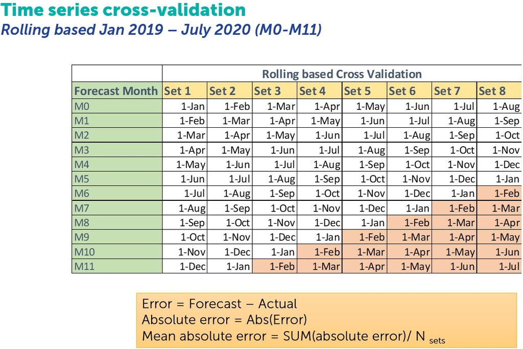

Model evaluation

```r
monthly_forecast <- calibration_tbl %>%
      mutate(year = year(DateTime), month = month(DateTime)) %>%
      left_join(Crude, c("year", "month")) %>%
      group_by(year, month) %>%
      summarise_if(is.numeric, mean, na.rm= T) %>%
      ungroup() %>%
      mutate(Date = make_date(year, month, 1),
             y_pred_hybrid = (y_pred_rf + y_pred_arima_xg) / 2,
             y_pred_hybrid2 = (y_pred_bsttree + y_pred_arimareg) / 2,
             y_pred_hybrid3 = (y_pred_arimareg + y_pred_svmpoly) / 2,
             dev_rf = y_pred_rf - !!rlang::sym(crackCol),
             dev_arima_xg = y_pred_arima_xg - !!rlang::sym(crackCol),
             dev_hybrid = y_pred_hybrid - !!rlang::sym(crackCol),
             dev_hybrid2 = y_pred_hybrid2 - !!rlang::sym(crackCol),
             dev_hybrid3 = y_pred_hybrid3 - !!rlang::sym(crackCol),
             dev_bsttree = y_pred_bsttree - !!rlang::sym(crackCol),
             dev_arimareg = y_pred_arimareg - !!rlang::sym(crackCol),
             dev_svmpoly = y_pred_svmpoly - !!rlang::sym(crackCol),
             dev_glmnet = y_pred_glmnet - !!rlang::sym(crackCol),
             Series = paste0("M", row_number()-1))%>%
      mutate_if(is.numeric, round, 2) %>%
      select(Date, year, month, !!rlang::sym(crackCol), Series, contains("y_pred"), contains("dev_"))
```

Sample output for MAD

[figure not shown]

MAD